# Risk Factor Analysis

## Outcome Variable

**Outcome Variable:** ever_stunted

## Predictor Variables

**Intervention Variable:** nchldlt5

**Adjustment Set:**

- arm
- W_mage
- meducyrs
- feducyrs
- hhwealth_quart
- hfoodsec
- W_mhtcm
- W_nrooms
- W_parity
- impfloor
- impsan
- safeh20
- delta_W_mage
- delta_meducyrs
- delta_feducyrs
- delta_hhwealth_quart
- delta_hfoodsec
- delta_W_mhtcm
- delta_W_nrooms
- delta_W_parity
- delta_impfloor
- delta_impsan
- delta_safeh20

## Stratifying Variables

The analysis was stratified on these variable(s):

- agecat
- studyid
- country

## Data Summary

| agecat | studyid | country | nchldlt5 | ever_stunted | n_cell | n |
| --- | --- | --- | --- | --- | --- | --- |
| 0-24 months | ki1000108-IRC | INDIA | 1 | 0 | 35 | 410 |
| 0-24 months | ki1000108-IRC | INDIA | 1 | 1 | 54 | 410 |
| 0-24 months | ki1000108-IRC | INDIA | 2+ | 0 | 112 | 410 |
| 0-24 months | ki1000108-IRC | INDIA | 2+ | 1 | 209 | 410 |
| 0-24 months | ki1017093b-PROVIDE | BANGLADESH | 1 | 0 | 295 | 700 |
| 0-24 months | ki1017093b-PROVIDE | BANGLADESH | 1 | 1 | 217 | 700 |
| 0-24 months | ki1017093b-PROVIDE | BANGLADESH | 2+ | 0 | 101 | 700 |
| 0-24 months | ki1017093b-PROVIDE | BANGLADESH | 2+ | 1 | 87 | 700 |
| 0-24 months | ki1017093c-NIH-Crypto | BANGLADESH | 1 | 0 | 298 | 758 |
| 0-24 months | ki1017093c-NIH-Crypto | BANGLADESH | 1 | 1 | 243 | 758 |
| 0-24 months | ki1017093c-NIH-Crypto | BANGLADESH | 2+ | 0 | 98 | 758 |
| 0-24 months | ki1017093c-NIH-Crypto | BANGLADESH | 2+ | 1 | 119 | 758 |
| 0-24 months | ki1066203-TanzaniaChild2 | TANZANIA, UNITED REPUBLIC OF | 1 | 0 | 1077 | 2385 |
| 0-24 months | ki1066203-TanzaniaChild2 | TANZANIA, UNITED REPUBLIC OF | 1 | 1 | 560 | 2385 |
| 0-24 months | ki1066203-TanzaniaChild2 | TANZANIA, UNITED REPUBLIC OF | 2+ | 0 | 481 | 2385 |
| 0-24 months | ki1066203-TanzaniaChild2 | TANZANIA, UNITED REPUBLIC OF | 2+ | 1 | 267 | 2385 |
| 0-24 months | ki1112895-iLiNS-Zinc | BURKINA FASO | 1 | 0 | 711 | 3188 |
| 0-24 months | ki1112895-iLiNS-Zinc | BURKINA FASO | 1 | 1 | 362 | 3188 |
| 0-24 months | ki1112895-iLiNS-Zinc | BURKINA FASO | 2+ | 0 | 1339 | 3188 |
| 0-24 months | ki1112895-iLiNS-Zinc | BURKINA FASO | 2+ | 1 | 776 | 3188 |
| 0-24 months | ki1148112-LCNI-5 | MALAWI | 1 | 0 | 145 | 812 |
| 0-24 months | ki1148112-LCNI-5 | MALAWI | 1 | 1 | 246 | 812 |
| 0-24 months | ki1148112-LCNI-5 | MALAWI | 2+ | 0 | 150 | 812 |
| 0-24 months | ki1148112-LCNI-5 | MALAWI | 2+ | 1 | 271 | 812 |
| 0-24 months | kiGH5241-JiVitA-3 | BANGLADESH | 1 | 0 | 8565 | 27209 |
| 0-24 months | kiGH5241-JiVitA-3 | BANGLADESH | 1 | 1 | 8849 | 27209 |
| 0-24 months | kiGH5241-JiVitA-3 | BANGLADESH | 2+ | 0 | 5206 | 27209 |
| 0-24 months | kiGH5241-JiVitA-3 | BANGLADESH | 2+ | 1 | 4589 | 27209 |
| 0-6 months | ki1000108-IRC | INDIA | 1 | 0 | 49 | 410 |
| 0-6 months | ki1000108-IRC | INDIA | 1 | 1 | 40 | 410 |
| 0-6 months | ki1000108-IRC | INDIA | 2+ | 0 | 187 | 410 |
| 0-6 months | ki1000108-IRC | INDIA | 2+ | 1 | 134 | 410 |
| 0-6 months | ki1017093b-PROVIDE | BANGLADESH | 1 | 0 | 384 | 700 |
| 0-6 months | ki1017093b-PROVIDE | BANGLADESH | 1 | 1 | 128 | 700 |
| 0-6 months | ki1017093b-PROVIDE | BANGLADESH | 2+ | 0 | 149 | 700 |
| 0-6 months | ki1017093b-PROVIDE | BANGLADESH | 2+ | 1 | 39 | 700 |
| 0-6 months | ki1017093c-NIH-Crypto | BANGLADESH | 1 | 0 | 386 | 758 |
| 0-6 months | ki1017093c-NIH-Crypto | BANGLADESH | 1 | 1 | 155 | 758 |
| 0-6 months | ki1017093c-NIH-Crypto | BANGLADESH | 2+ | 0 | 143 | 758 |
| 0-6 months | ki1017093c-NIH-Crypto | BANGLADESH | 2+ | 1 | 74 | 758 |
| 0-6 months | ki1066203-TanzaniaChild2 | TANZANIA, UNITED REPUBLIC OF | 1 | 0 | 1311 | 2385 |
| 0-6 months | ki1066203-TanzaniaChild2 | TANZANIA, UNITED REPUBLIC OF | 1 | 1 | 326 | 2385 |
| 0-6 months | ki1066203-TanzaniaChild2 | TANZANIA, UNITED REPUBLIC OF | 2+ | 0 | 609 | 2385 |
| 0-6 months | ki1066203-TanzaniaChild2 | TANZANIA, UNITED REPUBLIC OF | 2+ | 1 | 139 | 2385 |
| 0-6 months | ki1148112-LCNI-5 | MALAWI | 1 | 0 | 81 | 267 |
| 0-6 months | ki1148112-LCNI-5 | MALAWI | 1 | 1 | 41 | 267 |
| 0-6 months | ki1148112-LCNI-5 | MALAWI | 2+ | 0 | 91 | 267 |
| 0-6 months | ki1148112-LCNI-5 | MALAWI | 2+ | 1 | 54 | 267 |
| 0-6 months | kiGH5241-JiVitA-3 | BANGLADESH | 1 | 0 | 9822 | 27143 |
| 0-6 months | kiGH5241-JiVitA-3 | BANGLADESH | 1 | 1 | 7541 | 27143 |
| 0-6 months | kiGH5241-JiVitA-3 | BANGLADESH | 2+ | 0 | 6169 | 27143 |
| 0-6 months | kiGH5241-JiVitA-3 | BANGLADESH | 2+ | 1 | 3611 | 27143 |
| 6-24 months | ki1000108-IRC | INDIA | 1 | 0 | 35 | 236 |
| 6-24 months | ki1000108-IRC | INDIA | 1 | 1 | 14 | 236 |
| 6-24 months | ki1000108-IRC | INDIA | 2+ | 0 | 112 | 236 |
| 6-24 months | ki1000108-IRC | INDIA | 2+ | 1 | 75 | 236 |
| 6-24 months | ki1017093b-PROVIDE | BANGLADESH | 1 | 0 | 238 | 457 |
| 6-24 months | ki1017093b-PROVIDE | BANGLADESH | 1 | 1 | 89 | 457 |
| 6-24 months | ki1017093b-PROVIDE | BANGLADESH | 2+ | 0 | 82 | 457 |
| 6-24 months | ki1017093b-PROVIDE | BANGLADESH | 2+ | 1 | 48 | 457 |
| 6-24 months | ki1017093c-NIH-Crypto | BANGLADESH | 1 | 0 | 280 | 506 |
| 6-24 months | ki1017093c-NIH-Crypto | BANGLADESH | 1 | 1 | 88 | 506 |
| 6-24 months | ki1017093c-NIH-Crypto | BANGLADESH | 2+ | 0 | 93 | 506 |
| 6-24 months | ki1017093c-NIH-Crypto | BANGLADESH | 2+ | 1 | 45 | 506 |
| 6-24 months | ki1066203-TanzaniaChild2 | TANZANIA, UNITED REPUBLIC OF | 1 | 0 | 858 | 1596 |
| 6-24 months | ki1066203-TanzaniaChild2 | TANZANIA, UNITED REPUBLIC OF | 1 | 1 | 234 | 1596 |
| 6-24 months | ki1066203-TanzaniaChild2 | TANZANIA, UNITED REPUBLIC OF | 2+ | 0 | 376 | 1596 |
| 6-24 months | ki1066203-TanzaniaChild2 | TANZANIA, UNITED REPUBLIC OF | 2+ | 1 | 128 | 1596 |
| 6-24 months | ki1112895-iLiNS-Zinc | BURKINA FASO | 1 | 0 | 711 | 3188 |
| 6-24 months | ki1112895-iLiNS-Zinc | BURKINA FASO | 1 | 1 | 362 | 3188 |
| 6-24 months | ki1112895-iLiNS-Zinc | BURKINA FASO | 2+ | 0 | 1339 | 3188 |
| 6-24 months | ki1112895-iLiNS-Zinc | BURKINA FASO | 2+ | 1 | 776 | 3188 |
| 6-24 months | ki1148112-LCNI-5 | MALAWI | 1 | 0 | 138 | 705 |
| 6-24 months | ki1148112-LCNI-5 | MALAWI | 1 | 1 | 205 | 705 |
| 6-24 months | ki1148112-LCNI-5 | MALAWI | 2+ | 0 | 145 | 705 |
| 6-24 months | ki1148112-LCNI-5 | MALAWI | 2+ | 1 | 217 | 705 |
| 6-24 months | kiGH5241-JiVitA-3 | BANGLADESH | 1 | 0 | 5247 | 10520 |
| 6-24 months | kiGH5241-JiVitA-3 | BANGLADESH | 1 | 1 | 1308 | 10520 |
| 6-24 months | kiGH5241-JiVitA-3 | BANGLADESH | 2+ | 0 | 2987 | 10520 |
| 6-24 months | kiGH5241-JiVitA-3 | BANGLADESH | 2+ | 1 | 978 | 10520 |

The following strata were considered:

- agecat: 0-24 months, studyid: ki1000108-IRC, country: INDIA
- agecat: 0-24 months, studyid: ki1017093b-PROVIDE, country: BANGLADESH
- agecat: 0-24 months, studyid: ki1017093c-NIH-Crypto, country: BANGLADESH
- agecat: 0-24 months, studyid: ki1066203-TanzaniaChild2, country: TANZANIA, UNITED REPUBLIC OF
- agecat: 0-24 months, studyid: ki1112895-iLiNS-Zinc, country: BURKINA FASO
- agecat: 0-24 months, studyid: ki1148112-LCNI-5, country: MALAWI
- agecat: 0-24 months, studyid: kiGH5241-JiVitA-3, country: BANGLADESH
- agecat: 0-6 months, studyid: ki1000108-IRC, country: INDIA
- agecat: 0-6 months, studyid: ki1017093b-PROVIDE, country: BANGLADESH
- agecat: 0-6 months, studyid: ki1017093c-NIH-Crypto, country: BANGLADESH
- agecat: 0-6 months, studyid: ki1066203-TanzaniaChild2, country: TANZANIA, UNITED REPUBLIC OF
- agecat: 0-6 months, studyid: ki1148112-LCNI-5, country: MALAWI
- agecat: 0-6 months, studyid: kiGH5241-JiVitA-3, country: BANGLADESH
- agecat: 6-24 months, studyid: ki1000108-IRC, country: INDIA
- agecat: 6-24 months, studyid: ki1017093b-PROVIDE, country: BANGLADESH
- agecat: 6-24 months, studyid: ki1017093c-NIH-Crypto, country: BANGLADESH
- agecat: 6-24 months, studyid: ki1066203-TanzaniaChild2, country: TANZANIA, UNITED REPUBLIC OF
- agecat: 6-24 months, studyid: ki1112895-iLiNS-Zinc, country: BURKINA FASO
- agecat: 6-24 months, studyid: ki1148112-LCNI-5, country: MALAWI
- agecat: 6-24 months, studyid: kiGH5241-JiVitA-3, country: BANGLADESH

## Methods Detail

We’re interested in the causal parameters $E[Y_a]$ for all values of $a \in \mathcal{A}$. These parameters represent the mean outcome if, possibly contrary to fact, we intervened to set all units to have $A=a$. Under the randomization and positivity assumptions, these are identified by the statistical parameters $\psi_a=E_W[E_{Y|A,W}(Y|A=a,W)]$. In addition, we’re interested in the mean of $Y$, $E[Y]$ under no intervention (the observed mean). We will estimate these parameters by using SuperLearner to fit the relevant likelihood factors – $E_{Y|A,W}(Y|A=a,W)$ and $p(A=a|W)$, and then updating our likelihood fit using a joint TMLE.

For unadjusted analyses ($W=\{\}$), initial likelihoods were estimated using Lrnr_glm to estimate the simple $E(Y|A)$ and Lrnr_mean to estimate $p(A)$. For adjusted analyses, a small library containing Lrnr_glmnet, Lrnr_xgboost, and Lrnr_mean was used.

Having estimated these parameters, we will then use the delta method to estimate relative risks and attributable risks relative to a prespecified baseline level of $A$.

# Results Detail

## Results Plots

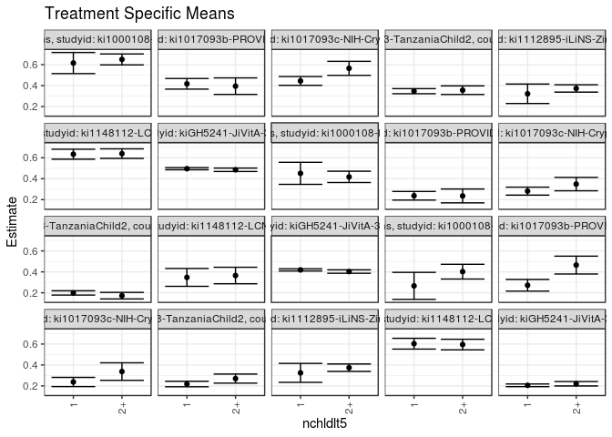

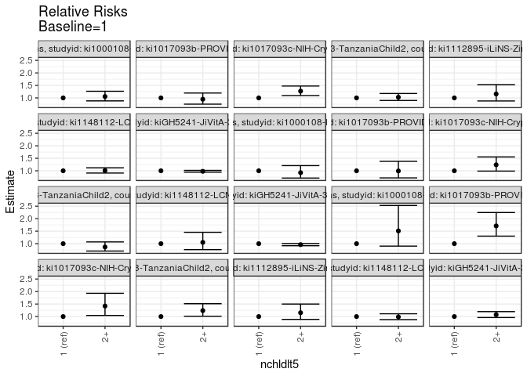

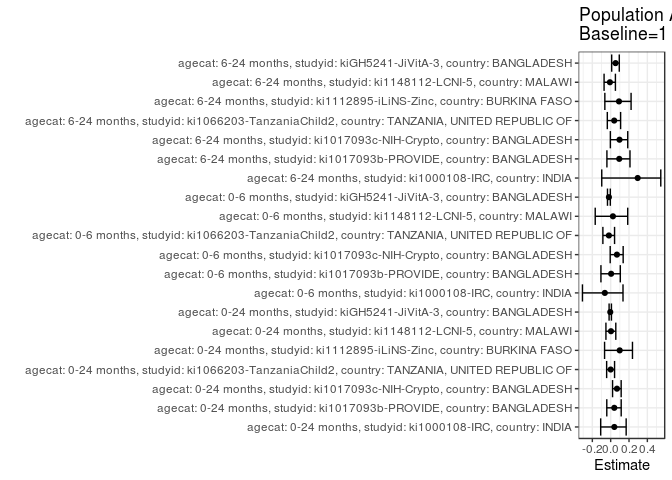

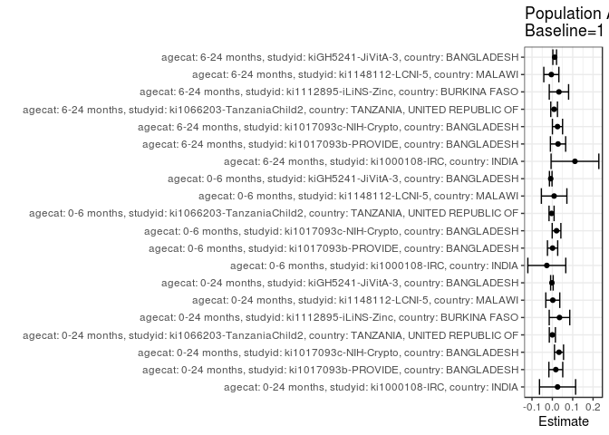

## Results Table

### Parameter: TSM

| agecat | studyid | country | intervention_level | baseline_level | estimate | ci_lower | ci_upper |
| --- | --- | --- | --- | --- | --- | --- | --- |
| 0-24 months | ki1000108-IRC | INDIA | 1 | NA | 0.6158334 | 0.5149164 | 0.7167505 |
| 0-24 months | ki1000108-IRC | INDIA | 2+ | NA | 0.6501000 | 0.5979238 | 0.7022761 |
| 0-24 months | ki1017093b-PROVIDE | BANGLADESH | 1 | NA | 0.4172013 | 0.3664494 | 0.4679532 |
| 0-24 months | ki1017093b-PROVIDE | BANGLADESH | 2+ | NA | 0.3948958 | 0.3160496 | 0.4737419 |
| 0-24 months | ki1017093c-NIH-Crypto | BANGLADESH | 1 | NA | 0.4447756 | 0.4029561 | 0.4865950 |
| 0-24 months | ki1017093c-NIH-Crypto | BANGLADESH | 2+ | NA | 0.5650107 | 0.4980650 | 0.6319565 |
| 0-24 months | ki1066203-TanzaniaChild2 | TANZANIA, UNITED REPUBLIC OF | 1 | NA | 0.3466957 | 0.3222486 | 0.3711428 |
| 0-24 months | ki1066203-TanzaniaChild2 | TANZANIA, UNITED REPUBLIC OF | 2+ | NA | 0.3563657 | 0.3152425 | 0.3974890 |
| 0-24 months | ki1112895-iLiNS-Zinc | BURKINA FASO | 1 | NA | 0.3218603 | 0.2288808 | 0.4148398 |
| 0-24 months | ki1112895-iLiNS-Zinc | BURKINA FASO | 2+ | NA | 0.3728798 | 0.3376024 | 0.4081573 |
| 0-24 months | ki1148112-LCNI-5 | MALAWI | 1 | NA | 0.6344579 | 0.5867622 | 0.6821537 |
| 0-24 months | ki1148112-LCNI-5 | MALAWI | 2+ | NA | 0.6399807 | 0.5942023 | 0.6857591 |
| 0-24 months | kiGH5241-JiVitA-3 | BANGLADESH | 1 | NA | 0.4960479 | 0.4857199 | 0.5063758 |
| 0-24 months | kiGH5241-JiVitA-3 | BANGLADESH | 2+ | NA | 0.4855704 | 0.4691581 | 0.5019827 |
| 0-6 months | ki1000108-IRC | INDIA | 1 | NA | 0.4515246 | 0.3461236 | 0.5569255 |
| 0-6 months | ki1000108-IRC | INDIA | 2+ | NA | 0.4177426 | 0.3636770 | 0.4718081 |
| 0-6 months | ki1017093b-PROVIDE | BANGLADESH | 1 | NA | 0.2373892 | 0.1962082 | 0.2785701 |
| 0-6 months | ki1017093b-PROVIDE | BANGLADESH | 2+ | NA | 0.2358126 | 0.1696594 | 0.3019659 |
| 0-6 months | ki1017093c-NIH-Crypto | BANGLADESH | 1 | NA | 0.2815327 | 0.2432977 | 0.3197678 |
| 0-6 months | ki1017093c-NIH-Crypto | BANGLADESH | 2+ | NA | 0.3488156 | 0.2846948 | 0.4129365 |
| 0-6 months | ki1066203-TanzaniaChild2 | TANZANIA, UNITED REPUBLIC OF | 1 | NA | 0.1987394 | 0.1782984 | 0.2191804 |
| 0-6 months | ki1066203-TanzaniaChild2 | TANZANIA, UNITED REPUBLIC OF | 2+ | NA | 0.1724396 | 0.1409403 | 0.2039388 |
| 0-6 months | ki1148112-LCNI-5 | MALAWI | 1 | NA | 0.3470488 | 0.2619281 | 0.4321695 |
| 0-6 months | ki1148112-LCNI-5 | MALAWI | 2+ | NA | 0.3650152 | 0.2862527 | 0.4437777 |
| 0-6 months | kiGH5241-JiVitA-3 | BANGLADESH | 1 | NA | 0.4187736 | 0.4086609 | 0.4288863 |
| 0-6 months | kiGH5241-JiVitA-3 | BANGLADESH | 2+ | NA | 0.4028542 | 0.3864917 | 0.4192166 |
| 6-24 months | ki1000108-IRC | INDIA | 1 | NA | 0.2660486 | 0.1369714 | 0.3951258 |
| 6-24 months | ki1000108-IRC | INDIA | 2+ | NA | 0.4019857 | 0.3314380 | 0.4725334 |
| 6-24 months | ki1017093b-PROVIDE | BANGLADESH | 1 | NA | 0.2717770 | 0.2159721 | 0.3275819 |
| 6-24 months | ki1017093b-PROVIDE | BANGLADESH | 2+ | NA | 0.4648305 | 0.3795786 | 0.5500825 |
| 6-24 months | ki1017093c-NIH-Crypto | BANGLADESH | 1 | NA | 0.2375262 | 0.1937286 | 0.2813238 |
| 6-24 months | ki1017093c-NIH-Crypto | BANGLADESH | 2+ | NA | 0.3371831 | 0.2533001 | 0.4210660 |
| 6-24 months | ki1066203-TanzaniaChild2 | TANZANIA, UNITED REPUBLIC OF | 1 | NA | 0.2180776 | 0.1919000 | 0.2442551 |
| 6-24 months | ki1066203-TanzaniaChild2 | TANZANIA, UNITED REPUBLIC OF | 2+ | NA | 0.2699588 | 0.2266229 | 0.3132947 |
| 6-24 months | ki1112895-iLiNS-Zinc | BURKINA FASO | 1 | NA | 0.3246019 | 0.2339876 | 0.4152162 |
| 6-24 months | ki1112895-iLiNS-Zinc | BURKINA FASO | 2+ | NA | 0.3742169 | 0.3387646 | 0.4096691 |
| 6-24 months | ki1148112-LCNI-5 | MALAWI | 1 | NA | 0.6035086 | 0.5519322 | 0.6550850 |
| 6-24 months | ki1148112-LCNI-5 | MALAWI | 2+ | NA | 0.5954059 | 0.5446219 | 0.6461898 |
| 6-24 months | kiGH5241-JiVitA-3 | BANGLADESH | 1 | NA | 0.2057344 | 0.1930161 | 0.2184527 |
| 6-24 months | kiGH5241-JiVitA-3 | BANGLADESH | 2+ | NA | 0.2207202 | 0.1995718 | 0.2418685 |

### Parameter: E(Y)

| agecat | studyid | country | intervention_level | baseline_level | estimate | ci_lower | ci_upper |
| --- | --- | --- | --- | --- | --- | --- | --- |
| 0-24 months | ki1000108-IRC | INDIA | NA | NA | 0.6414634 | 0.5949863 | 0.6879405 |
| 0-24 months | ki1017093b-PROVIDE | BANGLADESH | NA | NA | 0.4342857 | 0.3975409 | 0.4710305 |
| 0-24 months | ki1017093c-NIH-Crypto | BANGLADESH | NA | NA | 0.4775726 | 0.4419904 | 0.5131548 |
| 0-24 months | ki1066203-TanzaniaChild2 | TANZANIA, UNITED REPUBLIC OF | NA | NA | 0.3467505 | 0.3276457 | 0.3658553 |
| 0-24 months | ki1112895-iLiNS-Zinc | BURKINA FASO | NA | NA | 0.3569636 | 0.3068991 | 0.4070281 |
| 0-24 months | ki1148112-LCNI-5 | MALAWI | NA | NA | 0.6366995 | 0.6035988 | 0.6698003 |
| 0-24 months | kiGH5241-JiVitA-3 | BANGLADESH | NA | NA | 0.4938807 | 0.4860335 | 0.5017279 |
| 0-6 months | ki1000108-IRC | INDIA | NA | NA | 0.4243902 | 0.3764905 | 0.4722900 |
| 0-6 months | ki1017093b-PROVIDE | BANGLADESH | NA | NA | 0.2385714 | 0.2069753 | 0.2701675 |
| 0-6 months | ki1017093c-NIH-Crypto | BANGLADESH | NA | NA | 0.3021108 | 0.2694011 | 0.3348205 |
| 0-6 months | ki1066203-TanzaniaChild2 | TANZANIA, UNITED REPUBLIC OF | NA | NA | 0.1949686 | 0.1790654 | 0.2108717 |
| 0-6 months | ki1148112-LCNI-5 | MALAWI | NA | NA | 0.3558052 | 0.2982716 | 0.4133389 |
| 0-6 months | kiGH5241-JiVitA-3 | BANGLADESH | NA | NA | 0.4108610 | 0.4034098 | 0.4183122 |
| 6-24 months | ki1000108-IRC | INDIA | NA | NA | 0.3771186 | 0.3151523 | 0.4390850 |
| 6-24 months | ki1017093b-PROVIDE | BANGLADESH | NA | NA | 0.2997812 | 0.2577294 | 0.3418330 |
| 6-24 months | ki1017093c-NIH-Crypto | BANGLADESH | NA | NA | 0.2628458 | 0.2244546 | 0.3012371 |
| 6-24 months | ki1066203-TanzaniaChild2 | TANZANIA, UNITED REPUBLIC OF | NA | NA | 0.2268170 | 0.2062654 | 0.2473687 |
| 6-24 months | ki1112895-iLiNS-Zinc | BURKINA FASO | NA | NA | 0.3569636 | 0.3068991 | 0.4070281 |
| 6-24 months | ki1148112-LCNI-5 | MALAWI | NA | NA | 0.5985816 | 0.5623721 | 0.6347910 |
| 6-24 months | kiGH5241-JiVitA-3 | BANGLADESH | NA | NA | 0.2173004 | 0.2079295 | 0.2266713 |

### Parameter: RR

| agecat | studyid | country | intervention_level | baseline_level | estimate | ci_lower | ci_upper |
| --- | --- | --- | --- | --- | --- | --- | --- |
| 0-24 months | ki1000108-IRC | INDIA | 1 | 1 | 1.0000000 | 1.0000000 | 1.000000 |
| 0-24 months | ki1000108-IRC | INDIA | 2+ | 1 | 1.0556425 | 0.8805197 | 1.265595 |
| 0-24 months | ki1017093b-PROVIDE | BANGLADESH | 1 | 1 | 1.0000000 | 1.0000000 | 1.000000 |
| 0-24 months | ki1017093b-PROVIDE | BANGLADESH | 2+ | 1 | 0.9465353 | 0.7496584 | 1.195116 |
| 0-24 months | ki1017093c-NIH-Crypto | BANGLADESH | 1 | 1 | 1.0000000 | 1.0000000 | 1.000000 |
| 0-24 months | ki1017093c-NIH-Crypto | BANGLADESH | 2+ | 1 | 1.2703278 | 1.0944585 | 1.474457 |
| 0-24 months | ki1066203-TanzaniaChild2 | TANZANIA, UNITED REPUBLIC OF | 1 | 1 | 1.0000000 | 1.0000000 | 1.000000 |
| 0-24 months | ki1066203-TanzaniaChild2 | TANZANIA, UNITED REPUBLIC OF | 2+ | 1 | 1.0278919 | 0.8985237 | 1.175886 |
| 0-24 months | ki1112895-iLiNS-Zinc | BURKINA FASO | 1 | 1 | 1.0000000 | 1.0000000 | 1.000000 |
| 0-24 months | ki1112895-iLiNS-Zinc | BURKINA FASO | 2+ | 1 | 1.1585145 | 0.8770569 | 1.530295 |
| 0-24 months | ki1148112-LCNI-5 | MALAWI | 1 | 1 | 1.0000000 | 1.0000000 | 1.000000 |
| 0-24 months | ki1148112-LCNI-5 | MALAWI | 2+ | 1 | 1.0087047 | 0.9102715 | 1.117782 |
| 0-24 months | kiGH5241-JiVitA-3 | BANGLADESH | 1 | 1 | 1.0000000 | 1.0000000 | 1.000000 |
| 0-24 months | kiGH5241-JiVitA-3 | BANGLADESH | 2+ | 1 | 0.9788781 | 0.9430220 | 1.016098 |
| 0-6 months | ki1000108-IRC | INDIA | 1 | 1 | 1.0000000 | 1.0000000 | 1.000000 |
| 0-6 months | ki1000108-IRC | INDIA | 2+ | 1 | 0.9251824 | 0.7089478 | 1.207370 |
| 0-6 months | ki1017093b-PROVIDE | BANGLADESH | 1 | 1 | 1.0000000 | 1.0000000 | 1.000000 |
| 0-6 months | ki1017093b-PROVIDE | BANGLADESH | 2+ | 1 | 0.9933589 | 0.7160514 | 1.378060 |
| 0-6 months | ki1017093c-NIH-Crypto | BANGLADESH | 1 | 1 | 1.0000000 | 1.0000000 | 1.000000 |
| 0-6 months | ki1017093c-NIH-Crypto | BANGLADESH | 2+ | 1 | 1.2389879 | 0.9873433 | 1.554769 |
| 0-6 months | ki1066203-TanzaniaChild2 | TANZANIA, UNITED REPUBLIC OF | 1 | 1 | 1.0000000 | 1.0000000 | 1.000000 |
| 0-6 months | ki1066203-TanzaniaChild2 | TANZANIA, UNITED REPUBLIC OF | 2+ | 1 | 0.8676667 | 0.7039593 | 1.069445 |
| 0-6 months | ki1148112-LCNI-5 | MALAWI | 1 | 1 | 1.0000000 | 1.0000000 | 1.000000 |
| 0-6 months | ki1148112-LCNI-5 | MALAWI | 2+ | 1 | 1.0517691 | 0.7606686 | 1.454271 |
| 0-6 months | kiGH5241-JiVitA-3 | BANGLADESH | 1 | 1 | 1.0000000 | 1.0000000 | 1.000000 |
| 0-6 months | kiGH5241-JiVitA-3 | BANGLADESH | 2+ | 1 | 0.9619855 | 0.9185578 | 1.007467 |
| 6-24 months | ki1000108-IRC | INDIA | 1 | 1 | 1.0000000 | 1.0000000 | 1.000000 |
| 6-24 months | ki1000108-IRC | INDIA | 2+ | 1 | 1.5109482 | 0.9028518 | 2.528615 |
| 6-24 months | ki1017093b-PROVIDE | BANGLADESH | 1 | 1 | 1.0000000 | 1.0000000 | 1.000000 |
| 6-24 months | ki1017093b-PROVIDE | BANGLADESH | 2+ | 1 | 1.7103379 | 1.3020124 | 2.246719 |
| 6-24 months | ki1017093c-NIH-Crypto | BANGLADESH | 1 | 1 | 1.0000000 | 1.0000000 | 1.000000 |
| 6-24 months | ki1017093c-NIH-Crypto | BANGLADESH | 2+ | 1 | 1.4195616 | 1.0444589 | 1.929377 |
| 6-24 months | ki1066203-TanzaniaChild2 | TANZANIA, UNITED REPUBLIC OF | 1 | 1 | 1.0000000 | 1.0000000 | 1.000000 |
| 6-24 months | ki1066203-TanzaniaChild2 | TANZANIA, UNITED REPUBLIC OF | 2+ | 1 | 1.2379027 | 1.0127683 | 1.513084 |
| 6-24 months | ki1112895-iLiNS-Zinc | BURKINA FASO | 1 | 1 | 1.0000000 | 1.0000000 | 1.000000 |
| 6-24 months | ki1112895-iLiNS-Zinc | BURKINA FASO | 2+ | 1 | 1.1528485 | 0.8864721 | 1.499268 |
| 6-24 months | ki1148112-LCNI-5 | MALAWI | 1 | 1 | 1.0000000 | 1.0000000 | 1.000000 |
| 6-24 months | ki1148112-LCNI-5 | MALAWI | 2+ | 1 | 0.9865740 | 0.8758338 | 1.111316 |
| 6-24 months | kiGH5241-JiVitA-3 | BANGLADESH | 1 | 1 | 1.0000000 | 1.0000000 | 1.000000 |
| 6-24 months | kiGH5241-JiVitA-3 | BANGLADESH | 2+ | 1 | 1.0728402 | 0.9612199 | 1.197422 |

### Parameter: PAR

| agecat | studyid | country | intervention_level | baseline_level | estimate | ci_lower | ci_upper |
| --- | --- | --- | --- | --- | --- | --- | --- |
| 0-24 months | ki1000108-IRC | INDIA | 1 | NA | 0.0256300 | -0.0631237 | 0.1143836 |
| 0-24 months | ki1017093b-PROVIDE | BANGLADESH | 1 | NA | 0.0170844 | -0.0169306 | 0.0510994 |
| 0-24 months | ki1017093c-NIH-Crypto | BANGLADESH | 1 | NA | 0.0327970 | 0.0105372 | 0.0550568 |
| 0-24 months | ki1066203-TanzaniaChild2 | TANZANIA, UNITED REPUBLIC OF | 1 | NA | 0.0000548 | -0.0149177 | 0.0150273 |
| 0-24 months | ki1112895-iLiNS-Zinc | BURKINA FASO | 1 | NA | 0.0351033 | -0.0153436 | 0.0855502 |
| 0-24 months | ki1148112-LCNI-5 | MALAWI | 1 | NA | 0.0022416 | -0.0320312 | 0.0365144 |
| 0-24 months | kiGH5241-JiVitA-3 | BANGLADESH | 1 | NA | -0.0021672 | -0.0084630 | 0.0041287 |
| 0-6 months | ki1000108-IRC | INDIA | 1 | NA | -0.0271343 | -0.1203200 | 0.0660514 |
| 0-6 months | ki1017093b-PROVIDE | BANGLADESH | 1 | NA | 0.0011823 | -0.0239561 | 0.0263207 |
| 0-6 months | ki1017093c-NIH-Crypto | BANGLADESH | 1 | NA | 0.0205781 | -0.0007526 | 0.0419088 |
| 0-6 months | ki1066203-TanzaniaChild2 | TANZANIA, UNITED REPUBLIC OF | 1 | NA | -0.0037708 | -0.0161839 | 0.0086422 |
| 0-6 months | ki1148112-LCNI-5 | MALAWI | 1 | NA | 0.0087565 | -0.0539262 | 0.0714391 |
| 0-6 months | kiGH5241-JiVitA-3 | BANGLADESH | 1 | NA | -0.0079126 | -0.0142642 | -0.0015610 |
| 6-24 months | ki1000108-IRC | INDIA | 1 | NA | 0.1110700 | -0.0062115 | 0.2283515 |
| 6-24 months | ki1017093b-PROVIDE | BANGLADESH | 1 | NA | 0.0280042 | -0.0094514 | 0.0654598 |
| 6-24 months | ki1017093c-NIH-Crypto | BANGLADESH | 1 | NA | 0.0253196 | 0.0003921 | 0.0502472 |
| 6-24 months | ki1066203-TanzaniaChild2 | TANZANIA, UNITED REPUBLIC OF | 1 | NA | 0.0087395 | -0.0076757 | 0.0251547 |
| 6-24 months | ki1112895-iLiNS-Zinc | BURKINA FASO | 1 | NA | 0.0323617 | -0.0151157 | 0.0798391 |
| 6-24 months | ki1148112-LCNI-5 | MALAWI | 1 | NA | -0.0049270 | -0.0418971 | 0.0320431 |
| 6-24 months | kiGH5241-JiVitA-3 | BANGLADESH | 1 | NA | 0.0115660 | 0.0025615 | 0.0205704 |

### Parameter: PAF

| agecat | studyid | country | intervention_level | baseline_level | estimate | ci_lower | ci_upper |
| --- | --- | --- | --- | --- | --- | --- | --- |
| 0-24 months | ki1000108-IRC | INDIA | 1 | NA | 0.0399555 | -0.1089673 | 0.1688794 |
| 0-24 months | ki1017093b-PROVIDE | BANGLADESH | 1 | NA | 0.0393391 | -0.0424421 | 0.1147044 |
| 0-24 months | ki1017093c-NIH-Crypto | BANGLADESH | 1 | NA | 0.0686744 | 0.0206265 | 0.1143650 |
| 0-24 months | ki1066203-TanzaniaChild2 | TANZANIA, UNITED REPUBLIC OF | 1 | NA | 0.0001580 | -0.0439676 | 0.0424186 |
| 0-24 months | ki1112895-iLiNS-Zinc | BURKINA FASO | 1 | NA | 0.0983386 | -0.0665685 | 0.2377487 |
| 0-24 months | ki1148112-LCNI-5 | MALAWI | 1 | NA | 0.0035206 | -0.0517894 | 0.0559221 |
| 0-24 months | kiGH5241-JiVitA-3 | BANGLADESH | 1 | NA | -0.0043880 | -0.0172132 | 0.0082755 |
| 0-6 months | ki1000108-IRC | INDIA | 1 | NA | -0.0639372 | -0.3078285 | 0.1344719 |
| 0-6 months | ki1017093b-PROVIDE | BANGLADESH | 1 | NA | 0.0049556 | -0.1062287 | 0.1049650 |
| 0-6 months | ki1017093c-NIH-Crypto | BANGLADESH | 1 | NA | 0.0681144 | -0.0052909 | 0.1361598 |
| 0-6 months | ki1066203-TanzaniaChild2 | TANZANIA, UNITED REPUBLIC OF | 1 | NA | -0.0193408 | -0.0850126 | 0.0423562 |
| 0-6 months | ki1148112-LCNI-5 | MALAWI | 1 | NA | 0.0246103 | -0.1685314 | 0.1858284 |
| 0-6 months | kiGH5241-JiVitA-3 | BANGLADESH | 1 | NA | -0.0192586 | -0.0348158 | -0.0039354 |
| 6-24 months | ki1000108-IRC | INDIA | 1 | NA | 0.2945227 | -0.0973253 | 0.5464442 |
| 6-24 months | ki1017093b-PROVIDE | BANGLADESH | 1 | NA | 0.0934153 | -0.0410623 | 0.2105221 |
| 6-24 months | ki1017093c-NIH-Crypto | BANGLADESH | 1 | NA | 0.0963289 | -0.0033767 | 0.1861267 |
| 6-24 months | ki1066203-TanzaniaChild2 | TANZANIA, UNITED REPUBLIC OF | 1 | NA | 0.0385310 | -0.0366885 | 0.1082927 |
| 6-24 months | ki1112895-iLiNS-Zinc | BURKINA FASO | 1 | NA | 0.0906582 | -0.0636149 | 0.2225545 |
| 6-24 months | ki1148112-LCNI-5 | MALAWI | 1 | NA | -0.0082311 | -0.0719306 | 0.0516830 |
| 6-24 months | kiGH5241-JiVitA-3 | BANGLADESH | 1 | NA | 0.0532257 | 0.0109027 | 0.0937377 |